# Session 2. Web Structure Mining: Generalities, Complex Networks and Node-Centric Metrics

In this practical work, we will focus on Web Structure Mining in which data are interconnected and considered as a network to mine. We will first check if a network satisfies to constraints to be considered as a complex network and then, we will determine how important nodes are within a network.

## First, let's install the potentially missing libraries

(not necessary if you are certain these libs are installed on your system)

```python
! pip install pandas
! pip install networkx
! pip install seaborn
```

## Second, let's import the useful packages

You can avoid the first line if you are not using a Jupyter notebook. This line enables the visualization to be displayed in the notebook.

```python
%matplotlib inline

import networkx as nx
import pandas as pd
import seaborn as sns
from scipy import stats
import matplotlib.pyplot as plt
```

## Good, if you have not encounter any problems, we can start working now!

### First download the dataset (visit my professional web page)

```python
# Obviously, you must replace the path below by the appropriate path
path_pajek = "/Users/pitarch/Downloads/EVA/airports.net"
```

### Then, navigate through the documentation of the networkx package and find how to load networks in the pajek format

Note that the graph should be **directed**.

TIP: to create a directed simple graph after loading the pajek network, you must use the follwing instruction `g = nx.DiGraph(g)` where `g` is the loaded pajek network.

```python
? nx.read_pajek
```

```
Signature: nx.read_pajek(path, encoding='UTF-8')
Docstring:
Read graph in Pajek format from path.

Parameters
----------
path : file or string
   File or filename to write.
   Filenames ending in .gz or .bz2 will be uncompressed.

Returns
-------
G : NetworkX MultiGraph or MultiDiGraph.

Examples
--------
>>> G=nx.path_graph(4)
>>> nx.write_pajek(G, "test.net")
>>> G=nx.read_pajek("test.net")

To create a Graph instead of a MultiGraph use

>>> G1=nx.Graph(G)

References
----------
See http://vlado.fmf.uni-lj.si/pub/networks/pajek/doc/draweps.htm
for format information.
File:      ~/Pro/Soft/anaconda3/lib/python3.6/site-packages/networkx/readwrite/pajek.py
Type:      function
```

```python
# g = nx.read_adjlist(pathData, create_using=nx.DiGraph())
g = nx.read_pajek(path_pajek)
g = nx.DiGraph(g)
```

[output not shown]

[output cut: 317 more lines]

```python
g.node["Deadhorse"]
```

```
{'id': '2', 'shape': '0.5000', 'x': 0.483, 'y': 0.1014}
```

# Check the complex network properties

## Long-tail distribution

### Plot the degree distribution of the graph

1. Calculate and store the degree of each node
2. Convert the result (a dict) into a Pandas object, a Series
3. Use the seaborn `distplot` function to plot the degree distribution. Check the documenetation to set the parameters as follows: 20 bins and no gaussian kernel density estimate. Note that you must use the `plt.show()` instruction afterward to visualize the result.

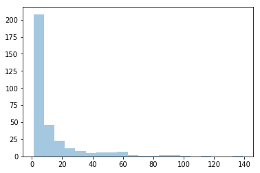

```python
deg = nx.degree(g)
df = pd.Series([y for (x,y) in deg])
# POUR VOUS : pd.Series([deg[x] for x in deg])
sns.distplot(df,bins=20, kde=False)
plt.show()
```

### Check if the graph satisfies the power-law degree property

Modify the call to the `distplot` function to graphically check if the degree distibution fits a power-law distribution. To do so, you should set the `fit` parameter to `stats.powerlaw`. Conclude.

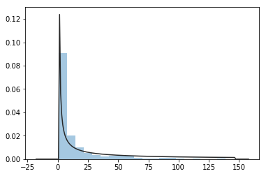

```python
sns.distplot(df,bins=20, kde=False, fit=stats.powerlaw)
plt.show()
```

## Small-world hypothesis

We now want to check if this network satisfies the small-world hypothesis. To do so, we are going to calculate the average shortest path between some nodes. In theory, all pairs should be considered. However, due to both resources and time constraint, it is acceptable to cinsider a sample of nodes only. You will apply the following methodology:

1. Convert the nodes into a Panda's series NON
2. Extract a sample from this series (size= 500) NON
3. For each pair from this subset, calculate the length of the shortest path and increment two variables accordingly (one to store the sum of the shortest path length and the other to store the number of calculated shortest paths)
4. Calculate and print the average

```python
#4 Check the small world hypothesis
sum = 0
count = 0

# For every possibles pairs, calculate the shortest path length
for i in g.nodes() :
    for j in g.nodes() :
        if i != j :
            try:
                shortest = nx.shortest_path_length(g,source=i, target=j)
                sum = sum + shortest
                count += 1
            except :
                pass

print("Average shortest path:", str(sum/count))
```

```
Average shortest path: 2.5639775322510956
```

### Check the strong community structure

To check how string is the community structure in this network, we will apply the following methodology:

1. Use the `gnm_random_graph` function to generate a random graph having the same number of vertices and edges than the studied network
2. Calculate the average clustering on both networks
3. Conclude

```python
# 5 Check the strong community structure
# Generate a random graph
gRandom = nx.gnm_random_graph(n=len(g.nodes()), m=len(g.edges()), directed = True)

cc = nx.transitivity(g)
cc_random = nx.transitivity(gRandom)

print(cc,cc_random)
```

```
0.2172385504351548 0.018235294117647058
```

# Node-Centric Metrics

We will now focus on the relative importance of vertices within the network. Luckily, many centrality metrics are implemented in networkx.

## Centrality Metrics

Have a look to the package documentation and calculate the following centralities:

1. degree
2. closeness
3. eigenvector
4. Katz
5. betweenness

```python
# g = nx.karate_club_graph()
```

```python
degreeCentrality= nx.degree_centrality(g)
closenessCentrality = nx.closeness_centrality(g)
eigenvectorCentrality = nx.eigenvector_centrality_numpy(g)
katzCentrality = nx.katz_centrality_numpy(g)
betweennessCentrality = nx.betweenness_centrality(g)
```

## Page Rank and HITS

Similarly to the previous question, have a look to the package documentation and calculate the following metrics:

1. Page Rank
2. Hub and Authorities (HITS)

```python
pagerank = nx.pagerank_scipy(g)
hubs, authorities = nx.hits_scipy(g)
```

## On the correlation of node-centric metrics

First, create a dataframe using with the above calculated centralities.

```python
dCentralities = {"label" : [x for x in degreeCentrality],
                 'degree' : [degreeCentrality[x] for x in degreeCentrality],
                 'closeness' : [closenessCentrality[x] for x in closenessCentrality],
                 'eigenVector' : [eigenvectorCentrality[x] for x in eigenvectorCentrality],
                 'katz' : [katzCentrality[x] for x in katzCentrality],
                 'betweenness' : [betweennessCentrality[x] for x in betweennessCentrality],
                 'pagerank' : [pagerank[x] for x in pagerank],
                 'hubs' : [hubs[x] for x in hubs],
                 'authorities' : [authorities[x] for x in authorities]
                }
```

```python
dfCentralities = pd.DataFrame.from_dict(dCentralities)
dfCentralities.set_index("label", inplace= True)
dfCentralities
```

| label | authorities | betweenness | closeness | degree | eigenVector | hubs | katz | pagerank |
| --- | --- | --- | --- | --- | --- | --- | --- | --- |
| Wiley Post-Will Rogers Mem | 0.000000e+00 | 0.000000 | 0.000000 | 0.009063 | 1.108963e-17 | 4.284492e-08 | 0.002943 | 0.000912 |
| Deadhorse | 5.993959e-10 | 0.000000 | 0.003021 | 0.009063 | 2.128757e-18 | 3.614751e-08 | 0.003237 | 0.001064 |
| Ralph Wien Memorial | 0.000000e+00 | 0.000000 | 0.000000 | 0.006042 | 4.080040e-17 | 3.516039e-08 | 0.002943 | 0.000912 |
| Fairbanks Intl | 1.651771e-09 | 0.000412 | 0.006042 | 0.015106 | 6.434125e-17 | 9.256842e-05 | 0.003561 | 0.001516 |
| Nome | 3.034827e-10 | 0.000000 | 0.003021 | 0.006042 | 8.924389e-17 | 3.540766e-08 | 0.003237 | 0.001100 |
| St Mary's | 0.000000e+00 | 0.000000 | 0.000000 | 0.009063 | -4.076865e-17 | 1.639710e-06 | 0.002943 | 0.000912 |
| Aniak | 1.036480e-08 | 0.000000 | 0.003021 | 0.009063 | -1.083255e-17 | 1.597703e-06 | 0.003237 | 0.001061 |
| Anchorage Intl | 1.149418e-06 | 0.013871 | 0.021148 | 0.087613 | 1.268831e-16 | 1.602143e-02 | 0.005153 | 0.004716 |
| Tuluksak | 0.000000e+00 | 0.000000 | 0.000000 | 0.012085 | -2.002363e-17 | 5.971420e-07 | 0.002943 | 0.000912 |
| Akiachak | 5.748129e-10 | 0.000000 | 0.003021 | 0.012085 | -2.663356e-17 | 2.591367e-07 | 0.003237 | 0.001076 |
| Akiak | 5.129933e-10 | 0.000000 | 0.006042 | 0.009063 | -9.196340e-17 | 3.718041e-07 | 0.003561 | 0.001261 |
| Kwethluk | 7.920849e-10 | 0.000000 | 0.006042 | 0.009063 | -3.400098e-17 | 2.253358e-07 | 0.003561 | 0.001322 |
| Bethel | 3.105194e-04 | 0.000769 | 0.025591 | 0.042296 | -8.615529e-17 | 7.612181e-52 | 0.005406 | 0.004249 |
| Napaskiak | 4.646947e-51 | 0.000000 | 0.017019 | 0.003021 | -1.027615e-16 | 0.000000e+00 | 0.003483 | 0.000986 |
| Napakiak | 5.679602e-51 | 0.000000 | 0.017019 | 0.003021 | -1.323299e-16 | 0.000000e+00 | 0.003483 | 0.001002 |
| Merle K (Mudhole) Smith | 1.228646e-04 | 0.000073 | 0.012890 | 0.006042 | 1.375532e-16 | 7.593516e-48 | 0.003458 | 0.000937 |
| Tuntutuliak | 3.097965e-50 | 0.000000 | 0.017019 | 0.009063 | -5.589550e-17 | 2.008677e-52 | 0.003483 | 0.001405 |
| Eek | 2.839801e-50 | 0.000000 | 0.017019 | 0.003021 | -1.102399e-16 | 0.000000e+00 | 0.003483 | 0.001364 |
| Kongiganak | 5.422849e-50 | 0.000000 | 0.019101 | 0.009063 | -1.788904e-16 | 4.282592e-53 | 0.003832 | 0.002190 |
| Kwigillingok | 6.557263e-50 | 0.000000 | 0.021242 | 0.009063 | -2.937934e-16 | 0.000000e+00 | 0.004215 | 0.004389 |
| Quinhagak | 5.060009e-50 | 0.000000 | 0.017019 | 0.003021 | -1.237199e-16 | 0.000000e+00 | 0.003483 | 0.001716 |
| Yakutat | 6.729316e-46 | 0.002124 | 0.010196 | 0.006042 | 7.419019e-17 | 4.378484e-06 | 0.003288 | 0.001709 |
| Dillingham | 2.457291e-04 | 0.000000 | 0.012890 | 0.006042 | 1.508453e-16 | 7.722283e-07 | 0.003458 | 0.000962 |
| King Salmon | 2.128306e-04 | 0.000000 | 0.015295 | 0.006042 | 2.773662e-16 | 0.000000e+00 | 0.003804 | 0.001774 |
| Gustavus | 0.000000e+00 | 0.000000 | 0.000000 | 0.003021 | -2.296657e-18 | 8.881622e-07 | 0.002943 | 0.000912 |
| Juneau Intl | 4.294433e-04 | 0.006637 | 0.020309 | 0.024169 | 2.035113e-16 | 4.515637e-05 | 0.004437 | 0.003576 |
| Kodiak | 1.804413e-04 | 0.000000 | 0.012890 | 0.003021 | 1.276534e-16 | 0.000000e+00 | 0.003458 | 0.000949 |
| St Paul Island | 5.649714e-04 | 0.000000 | 0.012890 | 0.006042 | 4.397370e-17 | 6.842761e-06 | 0.003458 | 0.001028 |
| Sitka | 1.898095e-07 | 0.000000 | 0.014502 | 0.012085 | 1.526971e-16 | 4.210839e-05 | 0.003386 | 0.001129 |
| Port Heiden | 3.063903e-04 | 0.000000 | 0.012890 | 0.006042 | 1.465255e-16 | 2.656539e-06 | 0.003458 | 0.000975 |
| ... | ... | ... | ... | ... | ... | ... | ... | ... |
| Corpus Christi Intl | 2.753552e-04 | 0.000000 | 0.265979 | 0.009063 | 1.125115e-02 | 0.000000e+00 | 0.070456 | 0.003224 |
| Laredo Intl | 2.460620e-04 | 0.000000 | 0.238906 | 0.003021 | 1.255330e-04 | 0.000000e+00 | 0.025923 | 0.001424 |
| Sarasota/Bradenton Intl | 1.353235e-02 | 0.000000 | 0.319620 | 0.057402 | 2.408673e-02 | 3.178810e-04 | 0.160272 | 0.006840 |
| Palm Beach Intl | 1.951793e-02 | 0.000012 | 0.324346 | 0.081571 | 2.440418e-02 | 2.338351e-04 | 0.184706 | 0.009582 |
| Southwest Florida Intl | 2.124828e-02 | 0.000033 | 0.334701 | 0.087613 | 6.592210e-02 | 2.231624e-04 | 0.223686 | 0.015336 |
| Rio Grande Valley Intl | 3.749370e-04 | 0.000000 | 0.268229 | 0.015106 | 2.263184e-02 | 0.000000e+00 | 0.100212 | 0.014286 |
| Mc Allen Miller Intl | 3.650355e-04 | 0.000000 | 0.263740 | 0.006042 | 5.389892e-03 | 0.000000e+00 | 0.052858 | 0.002941 |
| Fort Lauderdale/Hollywood Intl | 2.658802e-02 | 0.000065 | 0.342159 | 0.102719 | 1.011598e-01 | 3.472764e-05 | 0.245950 | 0.020819 |
| Miami Intl | 3.544867e-02 | 0.004402 | 0.370860 | 0.141994 | 2.141888e-01 | 1.655666e-03 | 0.356497 | 0.053600 |
| Lihue | 0.000000e+00 | 0.000000 | 0.000000 | 0.009063 | 5.340763e-17 | 1.830669e-04 | 0.002943 | 0.000912 |
| Honolulu Intl | 3.207050e-02 | 0.015133 | 0.305483 | 0.072508 | 4.029955e-04 | 4.118089e-04 | 0.117092 | 0.018622 |
| Molokai | 5.946150e-07 | 0.000000 | 0.210301 | 0.009063 | 3.430787e-04 | 9.807671e-06 | 0.014652 | 0.001002 |
| Kapalua | 9.513840e-07 | 0.000000 | 0.210301 | 0.009063 | 3.430787e-04 | 3.036087e-06 | 0.014652 | 0.001057 |
| Kahului | 6.435012e-03 | 0.000513 | 0.247577 | 0.030211 | 9.328815e-04 | 1.219979e-05 | 0.035281 | 0.004137 |
| Lanai | 9.626034e-07 | 0.000000 | 0.215165 | 0.012085 | 1.721401e-03 | 0.000000e+00 | 0.021110 | 0.002372 |
| Keahole-Kona Intll | 2.971920e-03 | 0.000148 | 0.243689 | 0.018127 | 1.142923e-03 | 5.280070e-09 | 0.035287 | 0.004833 |
| Hilo Intll | 2.853369e-06 | 0.000000 | 0.216171 | 0.009063 | 2.110256e-03 | 0.000000e+00 | 0.021709 | 0.007151 |
| Rafael Hernandez | 4.476989e-03 | 0.000000 | 0.256293 | 0.012085 | 1.823436e-01 | 8.979441e-06 | 0.041834 | 0.009620 |
| Luis Munoz Marin Intl | 2.375667e-02 | 0.003019 | 0.321475 | 0.063444 | 2.011662e-01 | 3.907308e-05 | 0.171561 | 0.025552 |
| Cyril E King | 6.240824e-03 | 0.000021 | 0.279157 | 0.027190 | 3.604601e-01 | 1.202534e-05 | 0.115490 | 0.021500 |
| Eugenio Maria De Hostos | 7.647774e-08 | 0.000000 | 0.226498 | 0.003021 | 1.712571e-01 | 0.000000e+00 | 0.020099 | 0.006027 |
| Mercedita | 4.582938e-03 | 0.000000 | 0.259727 | 0.015106 | 5.088337e-01 | 0.000000e+00 | 0.063174 | 0.022464 |
| Alexander Hamilton | 5.433201e-03 | 0.000000 | 0.269361 | 0.024169 | 6.672976e-01 | 0.000000e+00 | 0.109967 | 0.042759 |
| Johnston Atoll | 9.725259e-06 | 0.000000 | 0.210301 | 0.003021 | 3.430787e-04 | 0.000000e+00 | 0.014652 | 0.002390 |
| Saipan Intl | 0.000000e+00 | 0.000000 | 0.000000 | 0.012085 | 6.178292e-17 | 2.355571e-07 | 0.002943 | 0.000912 |
| Rota Intl | 7.029217e-10 | 0.000000 | 0.003021 | 0.006042 | 7.083766e-17 | 1.010554e-07 | 0.003237 | 0.000972 |
| Guam Intll | 3.978781e-05 | 0.002014 | 0.213540 | 0.012085 | 3.430787e-04 | 2.011751e-10 | 0.015270 | 0.007888 |
| Babelthuap/Koror | 7.072070e-09 | 0.000000 | 0.163261 | 0.006042 | 2.920703e-04 | 0.000000e+00 | 0.004764 | 0.008216 |
| Pago Pago Intl | 2.922890e-03 | 0.000000 | 0.232954 | 0.006042 | 3.486930e-04 | 0.000000e+00 | 0.025778 | 0.009792 |
| West Tinian | 9.825788e-11 | 0.000000 | 0.003021 | 0.003021 | 3.975266e-17 | 0.000000e+00 | 0.003237 | 0.000920 |

332 rows × 8 columns

Then, we will plot the pairwise relationships between centralities to have a first glimpse of the possible correlation between them. For this, use the `pairplot` function of the `seaborn` package.

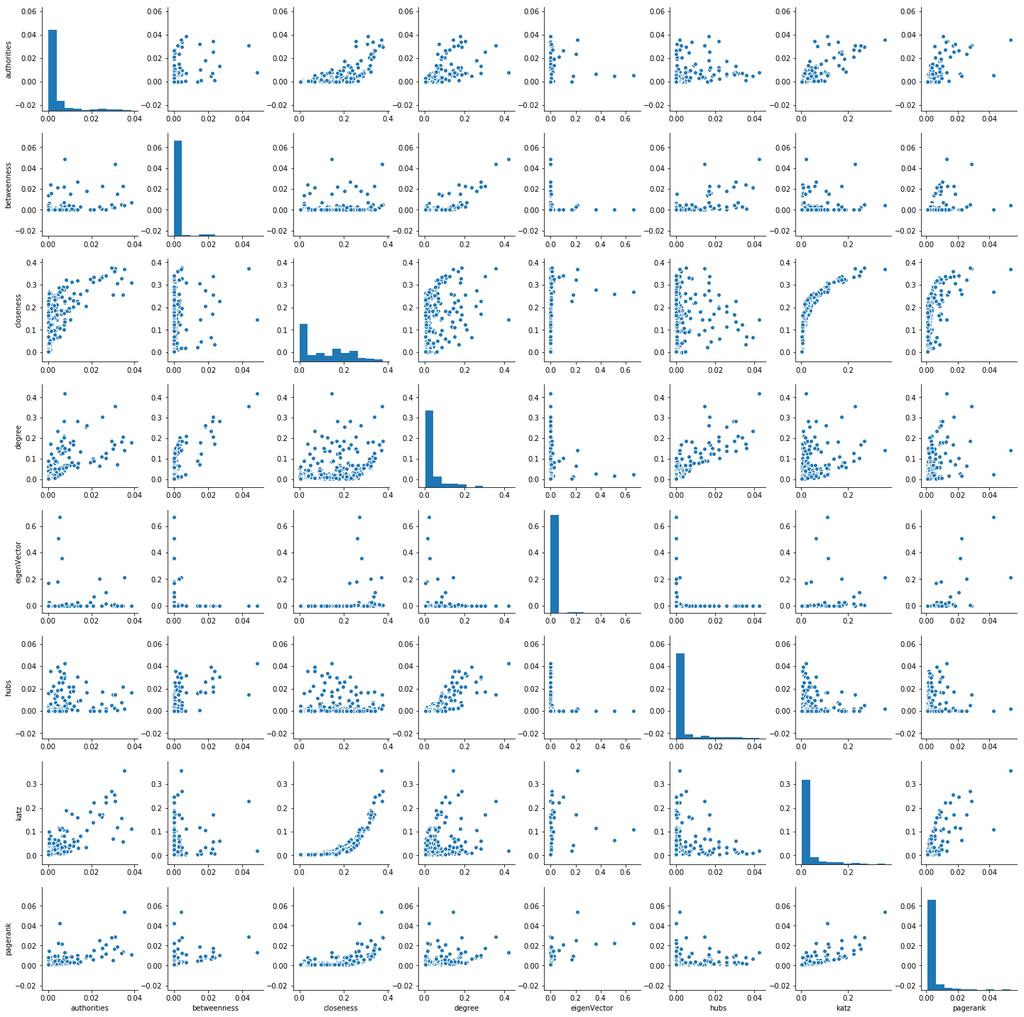

```python
sns.pairplot(dfCentralities)
```

We will now assess more properly these potential correlations. For this, use the `corr()` on your data frame. Be aware that the default method mignt not be appropriate to your case. Once the pairwise correlations have been calculated, we will plot the related method using the `heatmap()` function of the `seaborn` package. TIP: to change the color scheme, you can use the `cmap` parameter with value `plt.get_cmap(xxx)` where `xxx` is a color scheme (visit [this site](https://matplotlib.org/users/colormaps.html) to get the list of existing cholor schemes).

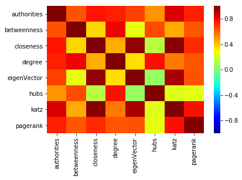

```python
corr = dfCentralities.corr(method='spearman')
sns.heatmap(corr, cmap=plt.get_cmap("jet"), vmin=-1, vmax = 1)
```

## On the finding of atypical vertices

As discussed during the lecture ans as you have just seen in the previous question, centrality metrics are often positively correlated. We will now find some key vertices in the network. Typically, these vertices are vertices that somehow "break" the positive pairwise correlations. You mission is to find at least one of these vertices. To do so, you will apply the following methodology:

1. Extract the 10 top airports per centrality metric
2. Comparethe list and conclude

```python
print(dfCentralities["degree"].nlargest(10).index)
print(dfCentralities["closeness"].nlargest(10).index)
print(dfCentralities["eigenVector"].nlargest(10).index)
print(dfCentralities["katz"].nlargest(10).index)
print(dfCentralities["betweenness"].nlargest(10).index)
```

```
Index(['Chicago O'hare Intl', 'Dallas/Fort Worth Intl',
       'The William B Hartsfield Atlan', 'Pittsburgh Intll',
       'Lambert-St Louis Intl', 'Charlotte/Douglas Intl', 'Stapleton Intl',
       'Minneapolis-St Paul Intl/Wold-', 'Detroit Metropolitan Wayne Cou',
       'San Francisco Intl'],
      dtype='object', name='label')
Index(['Houston Intercontinental', 'Dallas/Fort Worth Intl', 'Miami Intl',
       'Orlando Intl', 'Fort Lauderdale/Hollywood Intl', 'Tampa Intl',
       'The William B Hartsfield Atlan', 'Southwest Florida Intl',
       'San Diego Intl-Lindbergh Fld', 'Phoenix Sky Harbor Intl'],
      dtype='object', name='label')
Index(['Alexander Hamilton', 'Mercedita', 'Cyril E King', 'Miami Intl',
       'Luis Munoz Marin Intl', 'Rafael Hernandez', 'Eugenio Maria De Hostos',
       'Fort Lauderdale/Hollywood Intl', 'Southwest Florida Intl',
       'Palm Beach Intl'],
      dtype='object', name='label')
Index(['Miami Intl', 'Houston Intercontinental', 'Orlando Intl',
       'Fort Lauderdale/Hollywood Intl', 'Dallas/Fort Worth Intl',
       'Southwest Florida Intl', 'Tampa Intl', 'San Antonio Intl',
       'Palm Beach Intl', 'William P Hobby'],
      dtype='object', name='label')
Index(['Chicago O'hare Intl', 'Dallas/Fort Worth Intl',
       'Lambert-St Louis Intl', 'Seattle-Tacoma Intl', 'San Francisco Intl',
       'The William B Hartsfield Atlan', 'Pittsburgh Intll',
       'Minneapolis-St Paul Intl/Wold-', 'Stapleton Intl',
       'Charlotte/Douglas Intl'],
      dtype='object', name='label')
```

## Graph visualization

We will finally visualize the network to find some key vertices in the network. This can be useful to explain why some vertices play a crucial role in the network.

TIP 1: one way to fix the spatial position of the vertices is to use the vertex attributes `x` and `y`. To do so, you should create a dictionnary such that the keys are the labels of the vertices and the values are tuples isuch as `(x,y)` TIP 2: you can pass a dictionnary as parameter of the `draw_network` function to specify some visualization parameter, e.g., `nx.draw_network(g, **options)` where `options` is defined as:

```
options = {
    'node_color' : # either a color or a list with values (the vertex color will thus change according to the value) -- the size of the list should be the same as the number of vertices in the network
    'node_size' : 500,
    'cmap' : plt.get_cmap("jet"), # a color scheme (see below)
    #'vmin' : 0, # these two options are used to adjust the color scheme
    #'vmax' : 0.7 , # these two options are used to adjust the color scheme
    'node_shape' : 'o', # the shape of the node
    'with_labels' : True # print labels or not
}
```

```python
options = {
    'node_color' : dCentralities['pagerank'],
    'node_size' : 100,
    'cmap' : plt.get_cmap("jet"),
    #'vmin' : 0,
    #'vmax' : 0.7 ,
    'node_shape' : 'o',
    'with_labels' : False,
    "width" : 0.1

}
```

```python
pos = {}
for n in g.nodes():
    pos[n] = (g.node[n]['x'],g.node[n]['y'])
```

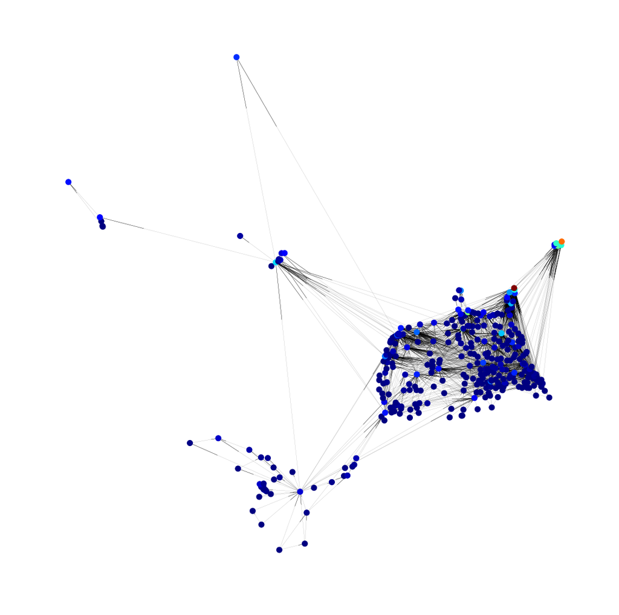

```python
plt.figure(figsize=(15,15))
nx.draw(g, pos=pos,**options)
#nx.draw(g,**options)
```